# STAT 428: Homework 6: Chapter 8 and 9 and Optimization

Fu, Xingyu, xingyuf2

Due Week 14 Saturday, December 1 by 11.59 PM on Compass

Please refer to the [**detailed homework policy document**](https://compass2g.illinois.edu/bbcswebdav/pid-3348982-dt-content-rid-35374883_1/courses/stat_428_120188_166591/1_Info/Syllabus/homework_policy.html) on Course Page for information about homework formatting, submission, and grading. Additional policies:

1. Whenever you are asked about an algorithm or a code implementing such, you have to either explain the algorithm clearly in steps or provide detailed documentation/comments on your R code explaining what you are doing. This is to ensure we fully understand what your code is trying to achieve since it can be hard to depict codes sometimes.
2. When using an R code chunk in the RmD with {r}, please use {r,eval=TRUE, echo=TRUE, include=TRUE} instead so that your chunk and results show in the html. This is just to help us grade faster.
3. When using external packages, please mention clearly what R packages you are using so that we can install those when running your codes. Furthermore, please call the package in your code using the “library” function so that your code shows no error when running.

## Exercise 1

**Maximum Likelihood Estimator** In the exercise parts that follow, you must show derivation by hand(typed up in latex from within RMarkdown), include code and plots where appropriate. Also, do compare your results from code with those you got by hand.

Suppose that $X$ is a discrete random variable with

- $\mathbb{P}(X= 0) = \displaystyle\frac{1}{4} \theta$;
- $\mathbb{P}(X= 1) = \displaystyle\frac{3}{4} \theta$;
- $\mathbb{P}(X= 2) = \displaystyle\frac{1}{4} (1-\theta)$;
- $\mathbb{P}(X= 3) = \displaystyle\frac{3}{4} (1-\theta)$;

where $0 \le \theta \le 1$ is a parameter. The following 10 independent observations were taken from such a distribution: $(3,0,2,1,3,2,1,0,2,1)$.

**(a)** What is the likelihood function $L(\theta$) for the sample $(3,0,2,1,3,2,1,0,2,1)$?
$$L(\theta) = [\mathbb{P}(X= 0)]^2 \cdot [\mathbb{P}(X= 1)]^3 \cdot [\mathbb{P}(X= 2)]^3 \cdot [\mathbb{P}(X= 3)]^2$$
$$= [\displaystyle\frac{1}{4} \theta]^2 \cdot [\displaystyle\frac{3}{4} \theta]^3 \cdot [\displaystyle\frac{1}{4} (1-\theta)]^3 \cdot [\displaystyle\frac{3}{4} (1-\theta)]^2$$
$$=\frac{3^5}{4^{10}} \cdot \theta^{5}(1-\theta)^5$$
**(b)** What is the log-likelihood function $l(\theta$) for the sample $(3,0,2,1,3,2,1,0,2,1)$?
$$l(\theta) = log(L(\theta))= 5log(3) - 10log(4) + 5 log(\theta) + 5 log(1- \theta) \propto 5 log(\theta) + 5 log(1- \theta)$$
**(c)** What is the maximum log-likelihood estimate of $\theta$? *(Hint: Recall the `optimize` function in R.)* maximum log-likelihood =
$$\underset{\theta}{\operatorname{argmax}} l(\theta) = \underset{\theta}{\operatorname{argmin}} -l(\theta)$$
let
$$-l'(\theta) = 0$$
,
Then
$$-\frac{5}{\theta} + \frac{5}{1-\theta} = 0$$
So we get at maximum
$$\theta = 0.5$$

```r
l <- function(x) {
  -5 * log(x) - 5 * log(1 - x)
}
theta_hat <- optimize(l, c(0, 1))
theta_hat
```

```
## $minimum
## [1] 0.5
##
## $objective
## [1] 6.931
```

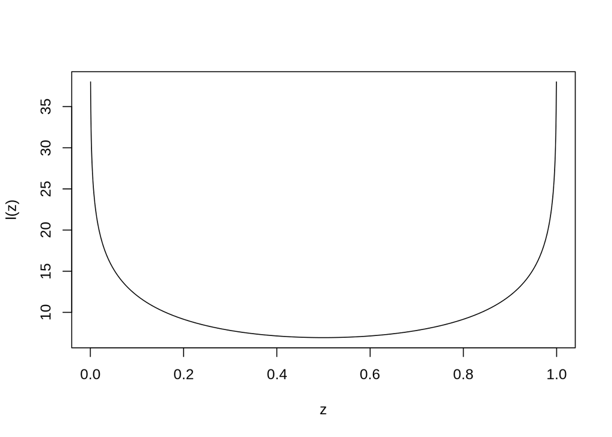

```r
z <- seq(0, 1, length=2000)
plot(z, l(z), type="l")
```

## Exercise 2

**Maximum Likelihood Estimator in Logistic Regression** Suppose we have data in pairs $(x_{i},y_{i})$ for $i=1,2,...,25$. Conditional on $x_{i}$, $y_{i}$ is Bernoulli with success probability

$$p_{i}=P[y_{i}=1|x_{i}]=exp(\beta_{0}+\beta_{1}x_{i})/(1+exp(\beta_{0}+\beta_{1}x_{i}))$$

The aim is to compute the maximum likelihood estimate $\hat{{\bf{\beta}}}$ of the parameter vector ${\bf{\beta}}=(\beta_{0},\beta_{1})^{T}$.

The log-likelihood is

$$\ell({\bf{\beta}})=\sum_{i=1}^{n}[y_{i}log(p_{i})+(1-y_{i})log(1-p_{i})]$$

The data are given below:

X values:

1.34 -1.38 -0.19 -0.44 1.90 -0.80 0.91 0.26 1.37 -1.62 -0.96 1.90 0.99 1.96 -1.57 1.51 -1.61 -1.02 -0.92 -1.87 1.73 -1.23 -1.24 0.22 1.42

Y values:

1 0 0 1 1 0 1 1 1 0 1 1 1 1 1 0 0 0 0 0 1 0 0 1 0

To input the data in R, you can just copy the following in R.

```r
x = c(1.34, -1.38, -0.19, -0.44, 1.90, -0.80, 0.91, 0.26, 1.37, -1.62, -0.96, 1.90, 0.99, 1.96, -1.57, 1.51, -1.61, -1.02, -0.92, -1.87,  1.73, -1.23, -1.24,  0.22, 1.42)
y = c(1, 0, 0, 1, 1, 0, 1, 1, 1, 0, 1, 1, 1, 1, 1, 0, 0, 0, 0, 0, 1, 0, 0, 1, 0)
```

**(a)** Use the function `optim()`to compute $\hat{{\bf{\beta}}}$ using initial value (.25,.75).

```r
x = c(1.34, -1.38, -0.19, -0.44, 1.90, -0.80, 0.91, 0.26, 1.37, -1.62, -0.96, 1.90, 0.99, 1.96, -1.57, 1.51, -1.61, -1.02, -0.92, -1.87,  1.73, -1.23, -1.24,  0.22, 1.42)
y = c(1, 0, 0, 1, 1, 0, 1, 1, 1, 0, 1, 1, 1, 1, 1, 0, 0, 0, 0, 0, 1, 0, 0, 1, 0)
l <- function(beta) {
  tmp <- exp(beta[1] + beta[2] * x)
  p <- tmp / (1 + tmp)
  return(sum(y * log(p) + (1 - y) * log(1 - p)))
}

betahat <- optim(par=c(0.25, 0.75), fn=l, control = list(fnscale=-1))$par
betahat
```

```
## [1] 0.1159 1.0286
```

**(b)** Again, starting with (.25,.75) find the next value when using the Newton-Raphson algorithm.

```r
library(numDeriv)

beta_init <- c(0.25, 0.75)
gradient <- grad(l, beta_init)
hess <- hessian(l, beta_init)
(nextbeta <- beta_init - solve(hess) %*% gradient)
```

```
##        [,1]
## [1,] 0.1269
## [2,] 0.9985
```

```r
(nextbeta <- array(nextbeta))
```

```
## [1] 0.1269 0.9985
```

**(c)** Assume that $\beta_{0}=0$, and plot the likelihood function $L(\beta_{1})$ as a function of $\beta_{1}$.

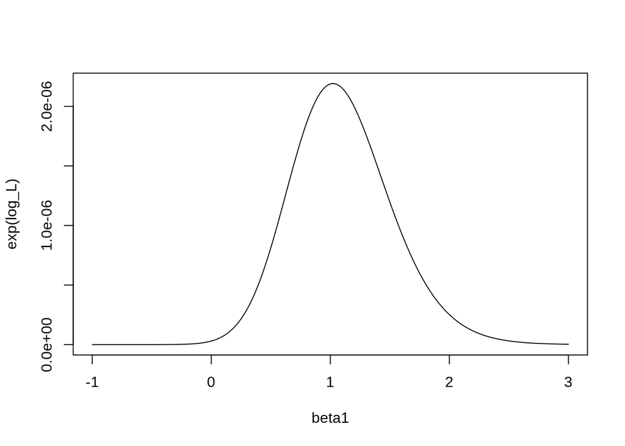

```r
l <- function(beta_0, beta_1) {
  tmp <- exp(beta_0 + beta_1 * x)
  p <- tmp / (1 + tmp)
  return(sum(y * log(p) + (1 - y) * log(1 - p)))
}

beta1 <- seq(-1, 3, length=1000)
log_L <- sapply(beta1, function(x) {l(0, x)})
plot(beta1, exp(log_L), type="l")
```

**(d)** Again, assume $\beta_{0}=0$ and compute $\hat{\beta}_{1}$ using `uniroot()`, a grid search, and by the Newton-Raphson algorithm. To use Uniroot, we need to calculate the derivative of likelihood.  
Let $p = \frac{u}{1 + u}$ where $u = exp(\beta_1 x)$  
Then $\frac{dp}{d\beta_1} = \frac{ux}{(1 + u)^2}$ So $\frac{dl}{d\beta_1} = \frac{dl}{dp} \frac{dp}{d\beta_1}$  
$= \frac{y}{p} \frac{ux}{(1+u)^2} - \frac{1-y}{1-p} \frac{ux}{(1+u)^2}$ $= \frac{(y + yT - T)x}{1 + T}$  
$= (y - p)x$

```r
# uniroot
dl <- function(beta1) {
  p <- exp(beta1 * x) / (1 + exp(beta1 * x))
  grad <- sum(x * (y - p)) # gradient of l about beta1
  return(grad)
}
(beta1_uni <- uniroot(dl, c(0, 2))$root)
```

```
## [1] 1.022
```

```r
beta1_uni
```

```
## [1] 1.022
```

```r
# Grid Search
grid <- seq(0, 2, 0.01)
res <- sapply(grid, function(beta) {l(0, beta)})
(beta1_g <- grid[res == max(res)])
```

```
## [1] 1.02
```

```r
#  the Newton-Raphson algorithm
Newton <- function(f, theres, x0, N){
  h = 1e-4
  i = 1
  p = numeric(N)
  while(i < N+1){
    x1 <- (x0 - (f(x0) / ((f(x0 + h) - f(x0)) / h)))
    p[i] <- x1
    if (abs(x1 - x0) < theres) break
    x0 <- x1
    i <- i + 1
  }
  return(x0)
}
(beta1_n <- Newton(dl, 1e-7, 0.8, 2000))
```

```
## [1] 1.022
```

We get beta_1 using `uniroot()`, grid search, and Newton-Raphson algorithm as 1.0219, 1.02 and 1.0219

## Exercise 3-8

Do the following problems from the book: 8.1, 9.2, 9.4, 9.7, 9.8, 9.10.

### 8.1

```r
library(latticeExtra)
```

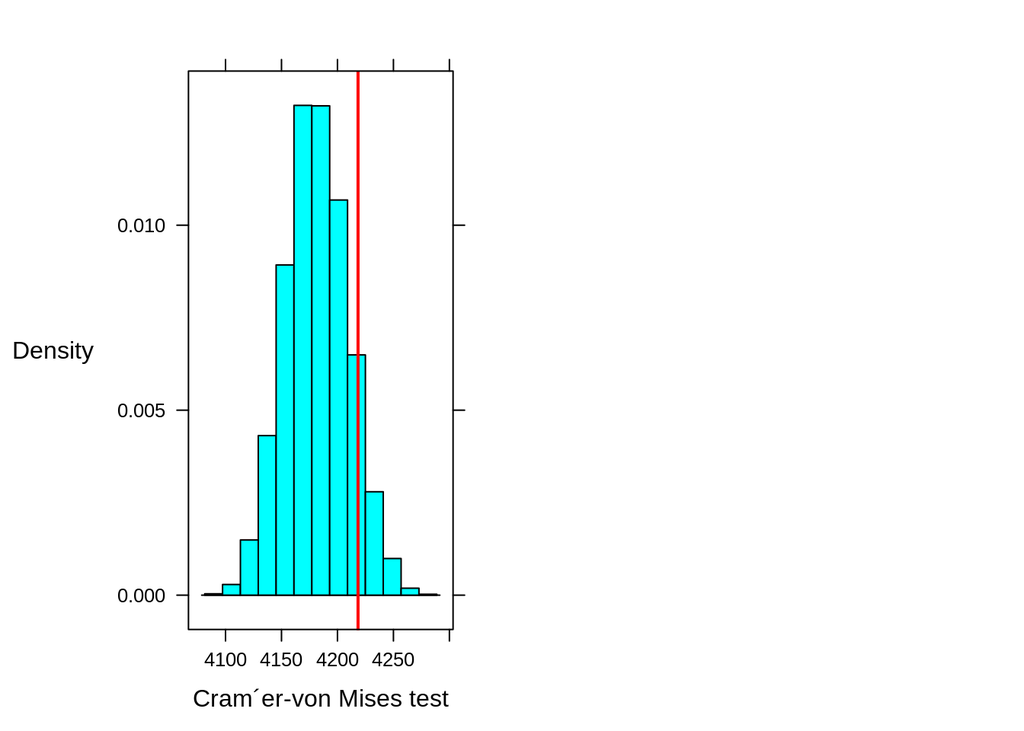

```r
# two-sample Cram´er-von Mises test
cm <- function(x, y){
  r <- 5000 # iteration
  t <- vector("numeric", r)
  n <- length(x)
  m <- length(y)
  n.v <- vector("numeric", n)
  n.v1 <- vector("numeric", n)
  m.v <- vector("numeric", m)
  m.v1 <- vector("numeric", m)
  z <- c(x, y)
  N <- length(z)
  for (i in 1:n)
    n.v[i] <- ( x[i] - i )**2
  for (j in 1:m)
    m.v[j] <- ( y[j] - j )**2

  # Test statistic for original dataset
  t_orig <- ( (n * sum(n.v) + m * sum(m.v)) / (m * n * N) ) - (4 * m * n - 1) / (6 * N)

  # Calculate test statistic for each permautation samples
  for (k in 1:r) {
    w <- sample(N, size = n, replace = FALSE)
    x1 <- sort( z[w] )
    y1 <- sort( z[-w] )
    for (i in 1:n) {
      n.v1[i] <- ( x1[i] - i )**2
    }
    for (j in 1:m) {
      m.v1[j] <- ( y1[j] - j )**2
    }
    t[k] <- ( (n * sum(n.v1) + m * sum(m.v1)) / (m * n * N) ) - (4 * m * n - 1) / (6 * N)
  }

  p <- mean( c(t_orig, t) >= t_orig )
  result = list("t_orig"=t_orig,"t"=t,"p"=p)
    return(result)
}

## plot
histplot <- function(t_orig,t){
  histogram(c(t_orig, t) , type = "density" , xlab = "Cram´er-von Mises test", ylab = list(rot = 0)
            , panel = function(...){
                panel.histogram(...)
                panel.abline(v = t_orig, col = 2, lwd = 2)
              }
            )
}

data("chickwts")
# 8.1
x <- with(chickwts, sort(as.vector(weight[feed == "soybean"])))
y <- with(chickwts, sort(as.vector(weight[feed == "linseed"])))
cvm_8.1 <- cm(x, y)
print(histplot(cvm_8.1$t_orig,cvm_8.1$t), position = c(0, 0, 0.5, 1))
```

```r
cvm_8.1$p
```

```
## [1] 0.09878
```

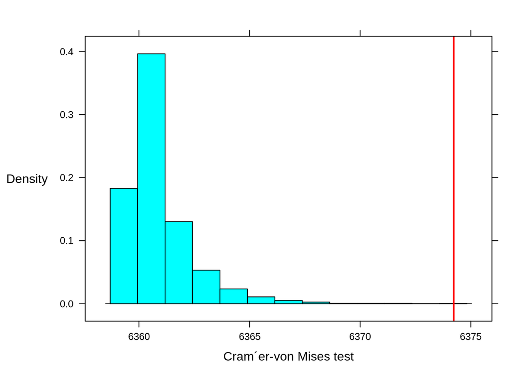

```r
# 8.2
x <- with(chickwts, sort(as.vector(weight[feed == "sunflower"])))
y <- with(chickwts, sort(as.vector(weight[feed == "linseed"])))
cvm_8.2 <- cm(x, y)
print(histplot(cvm_8.2$t_orig,cvm_8.2$t), position = c(0, 0, 1, 1))
```

```r
cvm_8.2$p
```

```
## [1] 0.0002
```

### 9.2

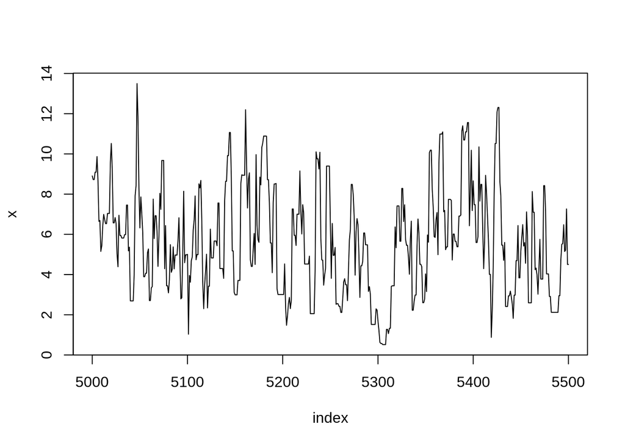

```r
f <- function(x, sigma){                      # Rayleigh density
  if (any(x < 0)) return (0)
  stopifnot(sigma > 0)
  return((x / sigma^2) * exp(-x^2 / (2*sigma^2)))
}
m1 <- 10000
sigma <- 4
x <- numeric(m1)
x[1] <- rgamma(1, shape = 1, rate = 1)        # gamma
k1 <- 0
u <- runif(m1)
for (i in 2:m1) {
  xt <- x[i-1]
  y <- rgamma(1, shape = xt, rate = 1)        # chi square distribution
  num <- f(y, sigma) * dgamma(xt, shape = y, rate = 1)
  den <- f(xt, sigma) * dgamma(y, shape = xt, rate = 1)
  if (u[i] <= num/den)
    x[i] <- y
  else {
    x[i] <- xt
    k1 <- k1+1   #y is rejected
  }
}
index <- 5000:5500
y1 <- x[index]
plot(index, y1, type="l", main="", ylab="x")
```

Approximately `29.86`% of the candidate points are rejected, so the chain is more efficient than simulation using chi square distribution.

### 9.4

```r
Lden=function(x){
  return (1/2*exp(-abs(x)))
}

rw.Metropolis <- function(sigma, x0, N) {
  x <- numeric(N)
  x[1] <- x0
  u <- runif(N)
  k <- 0
  for (i in 2:N) {
    y <- rnorm(1, x[i-1], sigma)
    if (u[i] <= (Lden(y) / Lden((x[i-1])))){
      x[i] <- y
      k=k+1
    }
    else {
      x[i] <- x[i-1]
    }
  }
  return(list(x=x, acrate=k/N))
}

N <- 2000
sigma <- c(0.05, 0.5, 2, 16)
x0 <- 25 # starting
rw1 <- rw.Metropolis(sigma[1], x0, N)
rw2 <- rw.Metropolis(sigma[2], x0, N)
rw3 <- rw.Metropolis(sigma[3], x0, N)
rw4 <- rw.Metropolis(sigma[4], x0, N)
# number of rejected candidate points
print(c(rw1$acrate, rw2$acrate, rw3$acrate, rw4$acrate))
```

```
## [1] 0.9865 0.8140 0.5500 0.0965
```

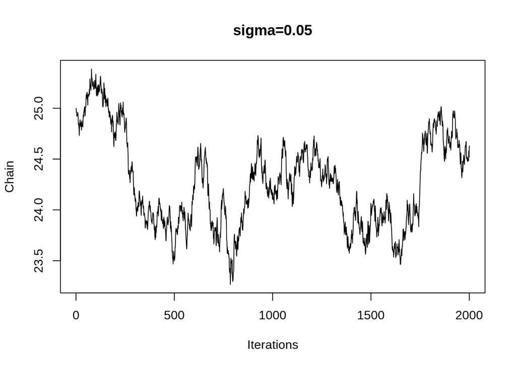

```r
# plot of chain
plot(rw1$x,type='l',ylab='Chain',xlab='Iterations',main='sigma=0.05')
```

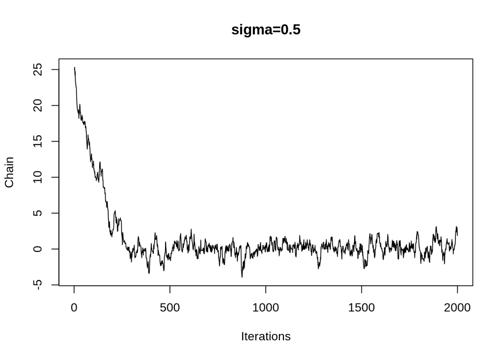

```r
plot(rw2$x,type='l',ylab='Chain',xlab='Iterations',main='sigma=0.5')
```

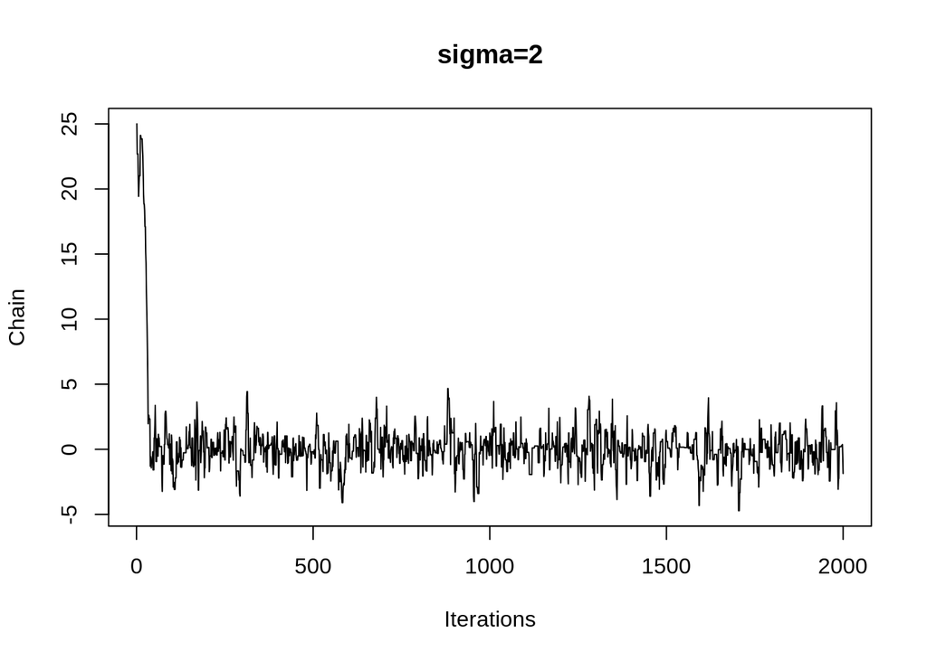

```r
plot(rw3$x,type='l',ylab='Chain',xlab='Iterations',main='sigma=2')
```

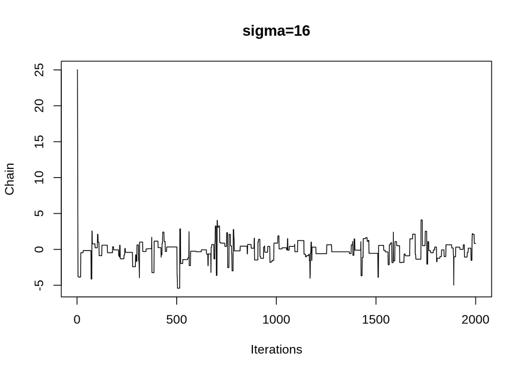

```r
plot(rw4$x,type='l',ylab='Chain',xlab='Iterations',main='sigma=16')
```

### 9.7

To generate (X,Y), we generate X and Y from X|Y and Y|X iteratively based on gibbs sampling.

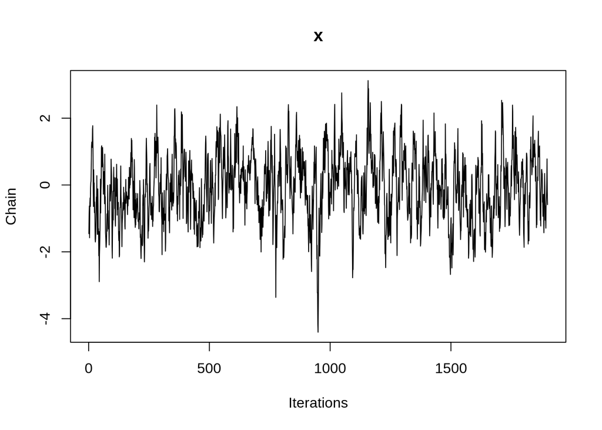

```r
x1 = 10   # inital point
burn = 100 # burn-in period
N = 2000 # length
x = numeric(N)
y = numeric(N)
x[1] = x1
y[1] = rnorm(1,0.9*x[1],sqrt(1-0.9^2))
for (i in 2:N){
  x[i] = rnorm(1,0.9*y[i-1],sqrt(1-0.9^2))
  y[i] = rnorm(1,0.9*x[i],sqrt(1-0.9^2))
}
xsample=x[(burn+1):N]
ysample=y[(burn+1):N]
# plot
plot(xsample,type='l',ylab='Chain',xlab='Iterations',main='x')
```

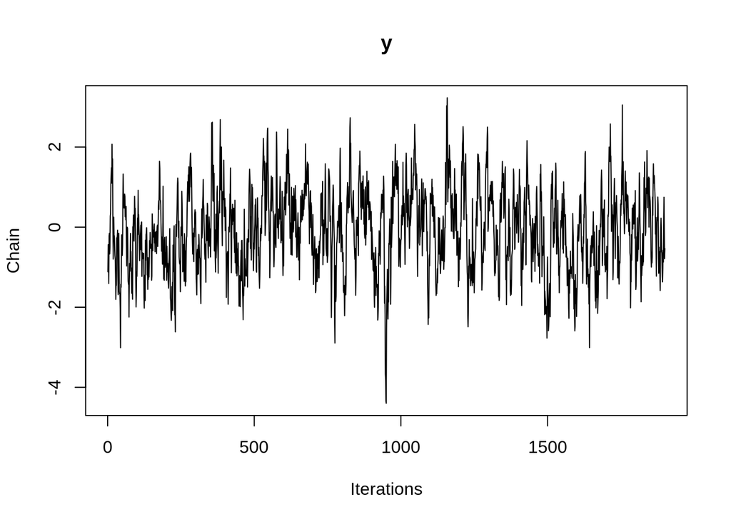

```r
plot(ysample,type='l',ylab='Chain',xlab='Iterations',main='y')
```

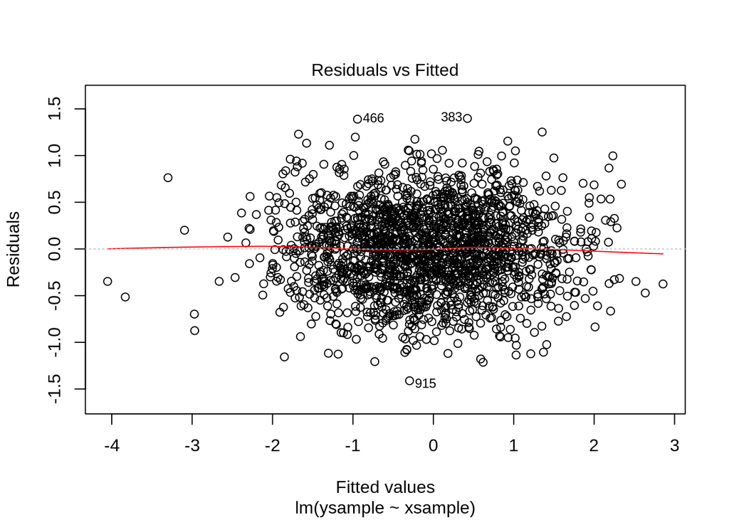

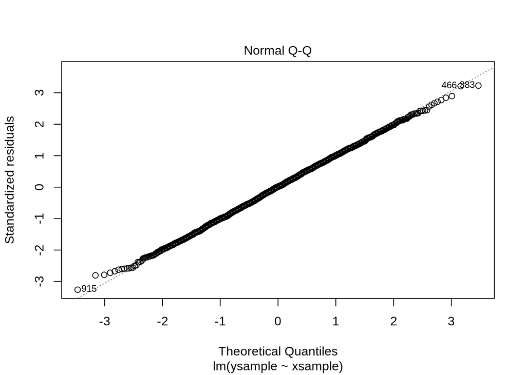

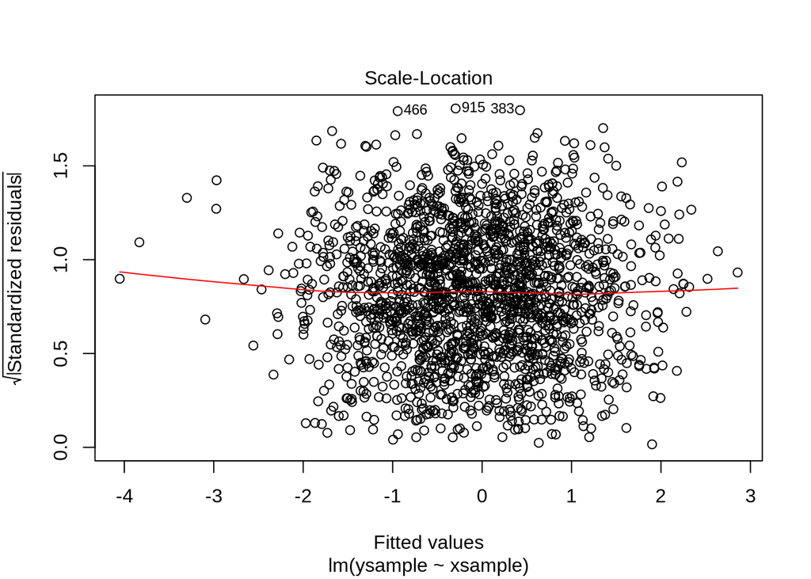

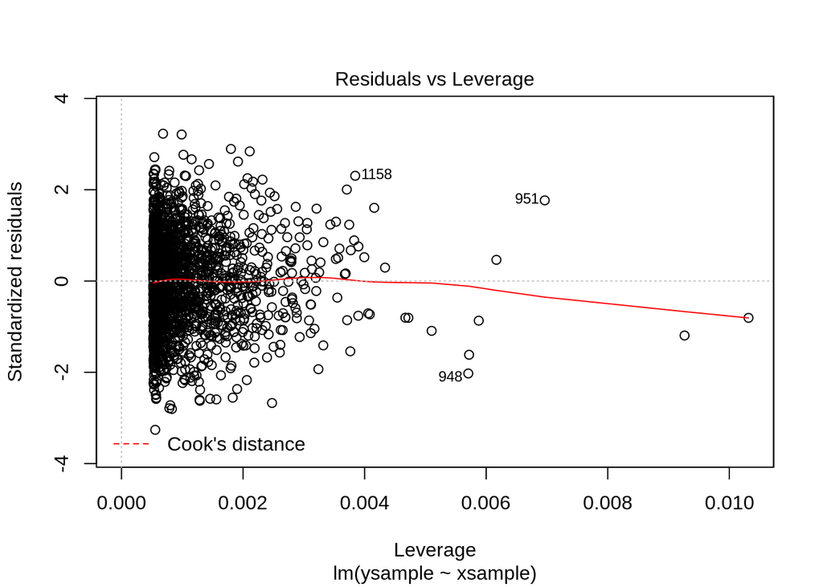

```r
# fit sample
modelfit=lm(ysample~xsample)
res=modelfit$residuals
plot(modelfit)
```

From the plots, residuals can indicate normality and constant variance in the regression model.

### 9.8

```r
gibbs.sim <- function(n,a,b){
  N <- 5000                           #iterations
  burn <- 1000
  X <- matrix(0, N, 2)
  # generate the chain
  X[1, ] <- c(floor(n/2), a/(a+b))
  for (i in 2:N){
    x2 <- X[i-1, 2]
    X[i, 1] <- rbinom(1, n, x2)
    x1 <- X[i, 1]
    X[i, 2] <- rbeta(1, x1+a, n-x1+b)
  }
  b <- burn + 1
  sample <- X[b:N, ]
  return(sample)
}
```

### 9.10

```r
#Defining the function to calculate the G-R statistic
Gelman.Rubin <- function(psi){
  # psi[i,j] is the statistic psi(X[i,1:j])
  # for chain in i-th row of X
  psi <- as.matrix(psi)
  n <- ncol(psi)
  k <- nrow(psi)
  psi.means <- rowMeans(psi)     #row means
  B <- n * var(psi.means)        #between variance est.
  psi.w <- apply(psi, 1, "var")  #within variances
  W <- mean(psi.w)               #within est.
  v.hat <- W*(n-1)/n + (B/n)     #upper variance est.
  r.hat <- v.hat / W             #G-R statistic
  return(r.hat)
}

f <- function(x, sigma){         # evaluate the Rayleigh density
  if (any(x < 0)) return (0)
  stopifnot(sigma > 0)
  return((x / sigma^2) * exp(-x^2 / (2*sigma^2)))
}

k <- 4                           # number chains
sigma <- 4
x <- as.matrix(c(0.01, 2, 4, 6))
ral.chain <- function(x){
  xi <- numeric(nrow(x))
  for(i in 1:length(xi)){
    xt <- x[i, ncol(x)]
    y <- rchisq(1, df = xt)      # Using chi square distribution
    num <- f(y, sigma) * dchisq(xt, df = y)
    den <- f(xt, sigma) * dchisq(y, df = xt)
    u <- runif(1)
    if (u <= num/den) xi[i] <- y else{
      xi[i] <- xt                #y is rejected
    }
  }
  return(cbind(x,xi))
}
r.hat = 10
while(r.hat >= 1.2){
  x <- ral.chain(x)
  psi <- t(apply(x, 1, cumsum))
  for (i in 1:nrow(psi))
    psi[i,] <- psi[i,] / (1:ncol(psi))
  r.hat <- Gelman.Rubin(psi)
}
b <- ncol(x)

# check convergence by the G-R method
library(coda)
x.mcmc <- mcmc.list(as.mcmc(x[1,]),as.mcmc(x[2,]),as.mcmc(x[3,]),as.mcmc(x[4,]))
geweke.diag(x.mcmc)
```

```
## [[1]]
##
## Fraction in 1st window = 0.1
## Fraction in 2nd window = 0.5
##
##    var1
## 0.03462
##
##
## [[2]]
##
## Fraction in 1st window = 0.1
## Fraction in 2nd window = 0.5
##
##    var1
## -0.4695
##
##
## [[3]]
##
## Fraction in 1st window = 0.1
## Fraction in 2nd window = 0.5
##
## var1
## 1.28
##
##
## [[4]]
##
## Fraction in 1st window = 0.1
## Fraction in 2nd window = 0.5
##
##    var1
## -0.1106
```

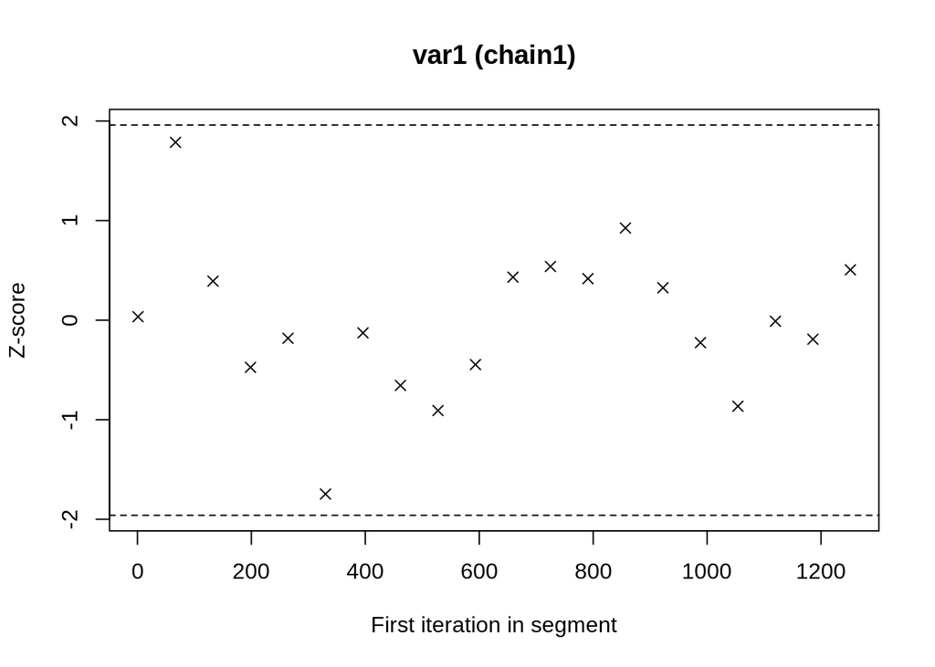

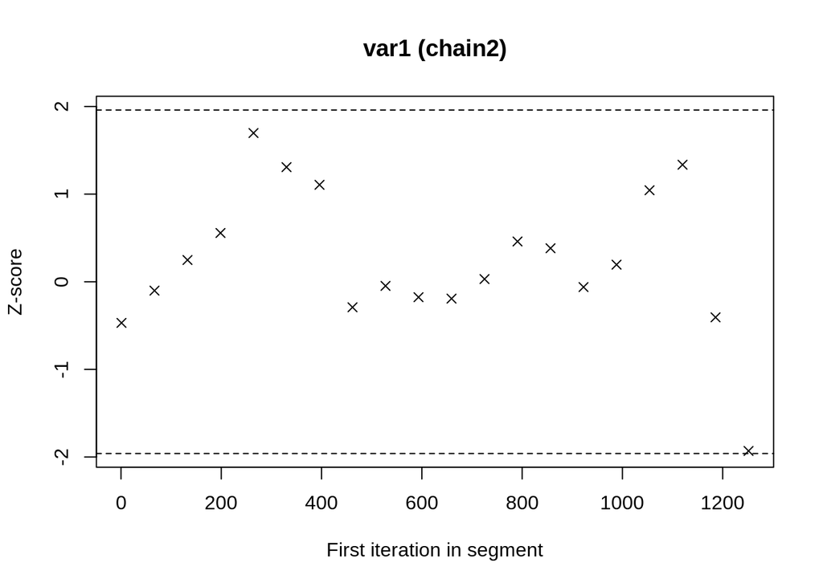

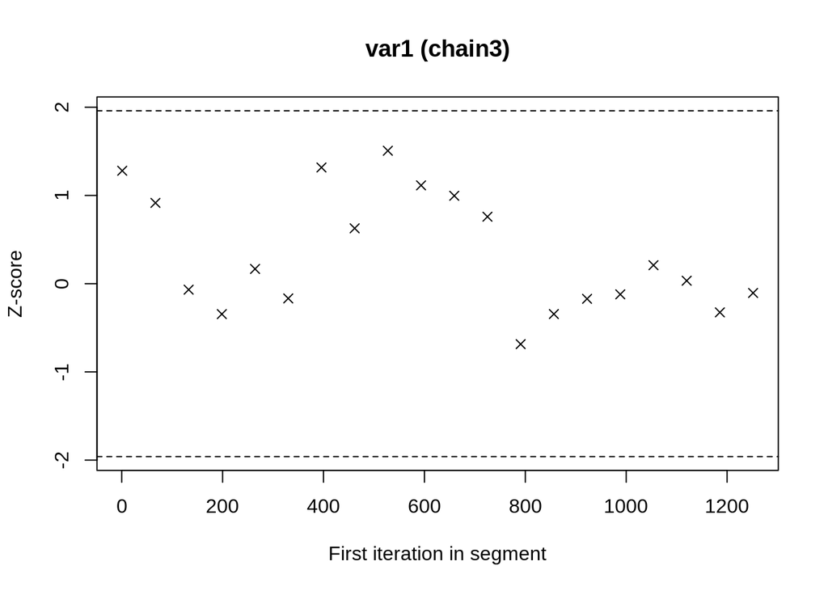

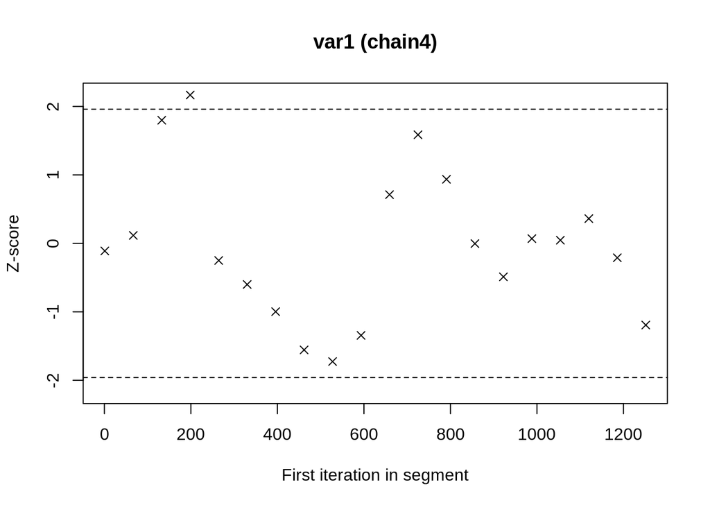

```r
geweke.plot(x.mcmc)
```

Our chains converge.